# **Milestone 1**

### **3. Box plot**

```python
# Let us write a function that will help us create boxplot w.r.t Price for any input categorical variable.
# This function takes the categorical column as the input and returns the boxplots for the variable.
def boxplot(z):

    plt.figure(figsize = (12, 5)) # Setting size of boxplot

    sns.boxplot(x = z, y = data['Price']) # Defining x and y

    plt.show()

    plt.figure(figsize = (12, 5))

    plt.title('Without Outliers')

    sns.boxplot(x = z, y = data['Price'], showfliers = False) # Turning off the outliers

    plt.show()
```

#### Let us now plot bivariate analysis of target variable with a categorical variable 'Location'

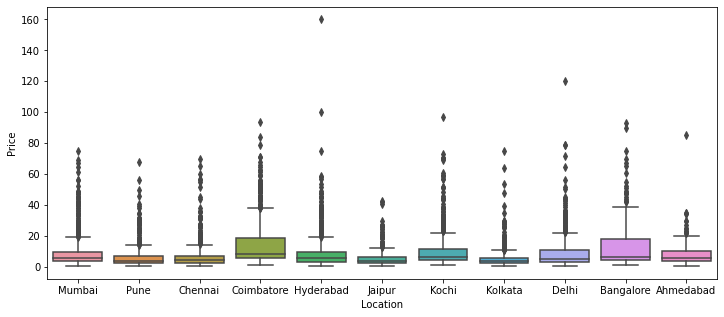

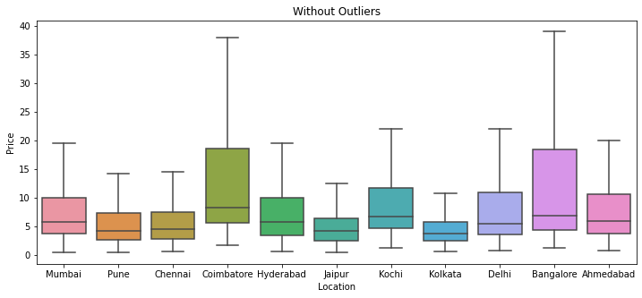

```python
# Box Plot: Price vs Location
boxplot(data['Location'])
```

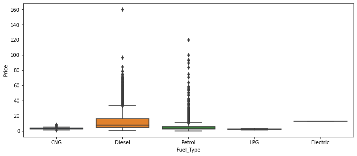

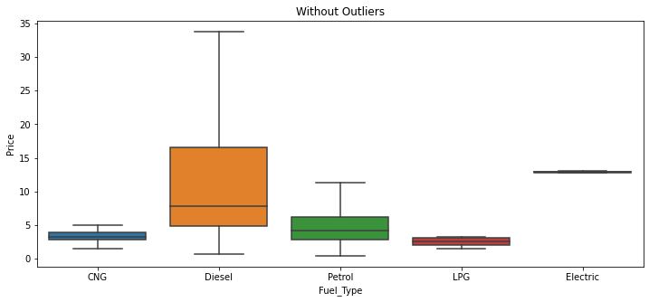

```python
# Box Plot: Price vs Fuel_Type
boxplot(data['Fuel_Type'])
```

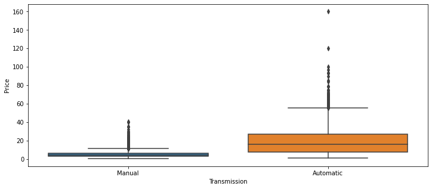

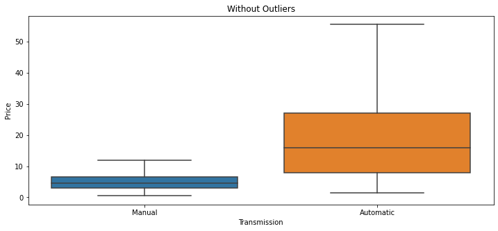

```python
# Box Plot: Price vs Transmission
boxplot(data['Transmission'])
```

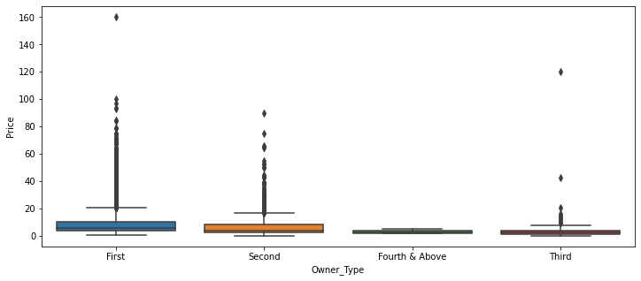

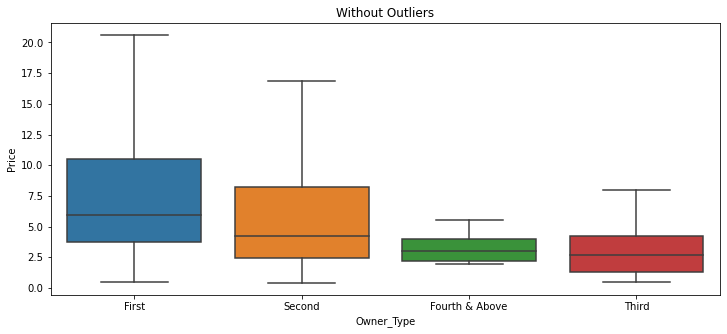

```python
# Box Plot: Price vs Owner_Type
boxplot(data['Owner_Type'])
```

**Note:** Explore by plotting box-plots for target variable and the other categorical variables like Fuel_Type, transmission, Owner_type.

**Observations and Insights for all plots:**

- Price for a car is higher in cities like Bangalore and Coimbatore compared to other cities in the analysis as well as diesel cars being considerably higher on average than other cars within this data set. This point could be misleading since there is a small sample size of used vehicles that are CNG, LPG, and electic
- Automatic transmission cars are considered to be more pricey when we remove the outliers within our data and cars that have fewer previous owners go for a higher premium than those who have had multiple owners

### **Feature Engineering**

**Think about it:** The `Name` column in the current format might not be very useful in our analysis. Since the name contains both the brand name and the model name of the vehicle, the column would have too many unique values to be useful in prediction. Can we extract that information from that column?

```python
#Replacing Car Brand Text

data.Name = data.Name.replace('Mini Countryman Cooper D', 'Mini Cooper Countryman D')
data.Name = data.Name.replace('ISUZU D-MAX V-Cross 4X4', 'Isuzu D-MAX V-Cross 4X4')
data.Name = data.Name.replace('Mini Clubman Cooper S', 'Mini Cooper Clubman S')
data.Name = data.Name.replace('OpelCorsa 1.4Gsi', 'Opel Corsa 1.4Gsi')
```

```python
car_brand = ['Hyundai', 'Honda', 'Volkswagen', 'Land Rover', 'Audi', 'Verna',
             'Maruti', 'Mitsubishi', 'Renault', 'Mercedes-Benz', 'BMW',
            'Toyota', 'Mahindra', 'Tata', 'Ford', 'Chevrolet', 'Datsun',
            'Skoda', 'Jeep', 'Nissan', 'Acura', 'Alfa Romeo', 'Buick', 'Dodge',
            'Fiat', 'GMC', 'Lexus', 'Lincoln', 'Mazda', 'Pontiac', 'Porsche',
            'Jaguar', 'Volvo', 'Mini Cooper', 'Smart', 'Ambassador', 'Isuzu',
            'Bentley', 'Hindustan', 'Lamborghini', 'Force One', 'Opel']
pat=r'({})'.format('|'.join(car_brand))
```

```python
data['car_brand']=data.Name.str.extract(pat)
data['car_model']=data.pop('Name').str.replace(pat,'').str.strip()
```

```python
data.car_brand.isna().sum()
```

```
0
```

```python
data.car_model.isna().sum()
```

```
0
```

```python
data.info()
```

```
<class 'pandas.core.frame.DataFrame'>
Int64Index: 7252 entries, 0 to 7252
Data columns (total 18 columns):
 #   Column                 Non-Null Count  Dtype
---  ------                 --------------  -----
 0   Location               7252 non-null   object
 1   Year                   7252 non-null   int64
 2   Kilometers_Driven      7252 non-null   int64
 3   Fuel_Type              7252 non-null   object
 4   Transmission           7252 non-null   object
 5   Owner_Type             7252 non-null   object
 6   Mileage                7250 non-null   float64
 7   Engine                 7206 non-null   float64
 8   Power                  7077 non-null   float64
 9   Seats                  7199 non-null   float64
 10  New_price              1006 non-null   float64
 11  Price                  6018 non-null   float64
 12  kilometers_driven_log  7252 non-null   float64
 13  Price_log              6018 non-null   float64
 14  Power_log              7077 non-null   float64
 15  New_Price_log          1006 non-null   float64
 16  car_brand              7252 non-null   object
 17  car_model              7252 non-null   object
dtypes: float64(10), int64(2), object(6)
memory usage: 1.1+ MB
```

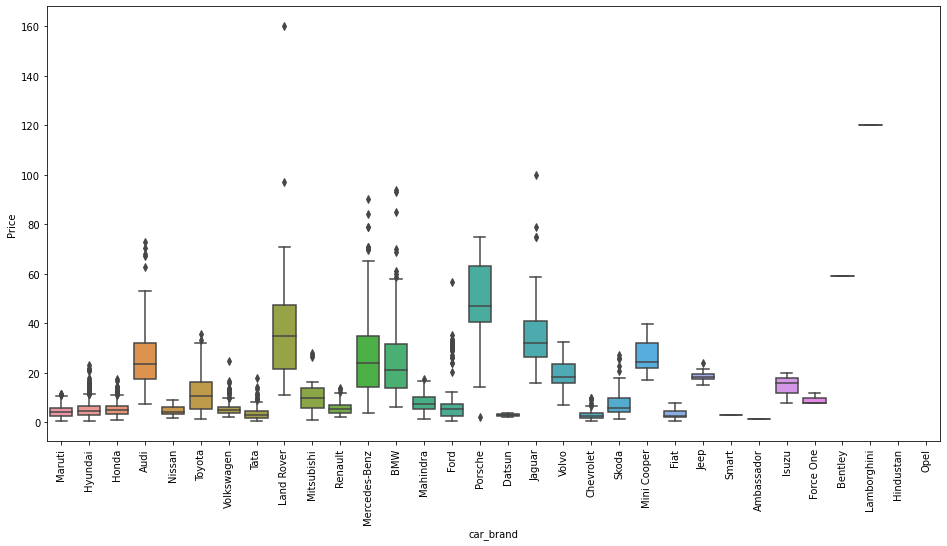

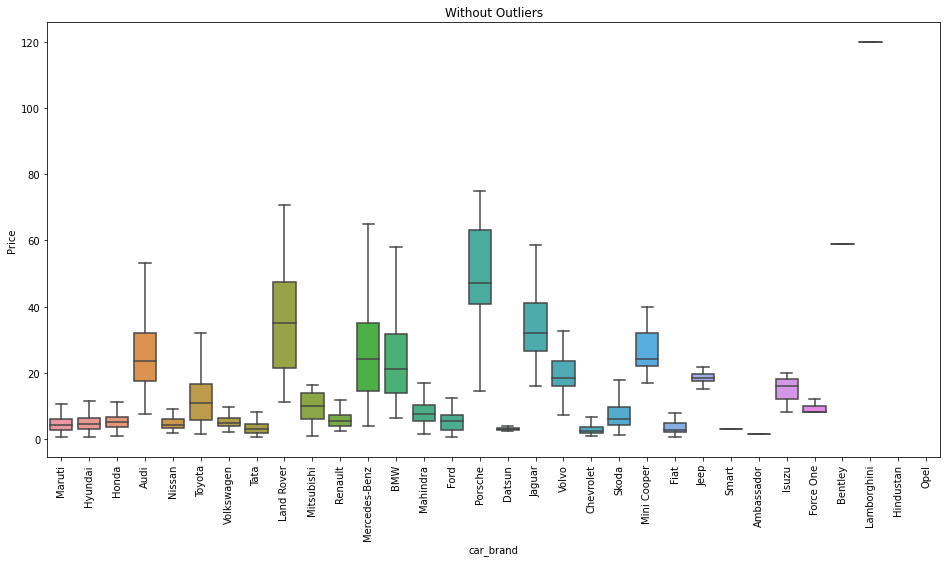

```python
plt.figure(figsize = (16, 8)) # Setting size of boxplot

sns.boxplot(x = data['car_brand'], y = data['Price']) # Defining x and y

plt.xticks(rotation = 90)

plt.show()

plt.figure(figsize = (16, 8))

plt.title('Without Outliers')

sns.boxplot(x = data['car_brand'], y = data['Price'], showfliers = False) # Turning off the outliers

plt.xticks(rotation = 90)

plt.show()
```

- **Hint:** With 2041 unique names, car names are not going to be great predictors of the price in our current data. But we can process this column to extract important information for example brand name.

### **Missing value treatment**

```python
# Now check the missing values of each column. Hint: Use isnull() method
data.isnull().sum()
```

```
Location                    0
Year                        0
Kilometers_Driven           0
Fuel_Type                   0
Transmission                0
Owner_Type                  0
Mileage                     2
Engine                     46
Power                     175
Seats                      53
New_price                6246
Price                    1234
kilometers_driven_log       0
Price_log                1234
Power_log                 175
New_Price_log            6246
car_brand                   0
car_model                   0
dtype: int64
```

#### **Observations and Insights:**

**Missing values in Seats**

```python
# Checking missing values in the column 'Seats'
data.Seats.isnull().sum()
```

```
53
```

**Think about it:** Can we somehow use the extracted information from 'Name' column to impute missing values?

**Hint:** Impute these missing values one by one, by taking median number of seats for the particular car, using the Brand and Model name.

```python
# Impute missing values in Seats,you can use fillna method in pandas
data['Seats'] = data['Seats'].fillna(data.groupby(['car_brand', 'car_model'])['Seats'].transform('median'))
```

```python
# Now check total number of missing values of the seat column to verify if they are imputed or not. Hint: Use isnull() method
data['Seats'].isnull().sum()
```

```
46
```

**Missing values for Mileage**

```python
# Now check missing values of each column. Hint: Use isnull() method
data['Mileage'].isnull().sum()
```

```
2
```

```python
# Impute missing Mileage. For example, use can use median or any other methods.
data['Mileage'] = data['Mileage'].fillna(data.groupby(['car_brand', 'car_model'])['Mileage'].transform('median'))
```

```python
# Now check total number of missing values of the seat column to verify if they are imputed or not. Hint: Use isnull() method
data['Mileage'].isnull().sum()
```

```
2
```

**Missing values for Engine**

```python
# Now check missing values of each column. Hint: Use isnull() method
data['Engine'].isnull().sum()
```

```
46
```

```python
# Impute missing Engine. For example, use can use median or any other methods.
data['Engine'] = data['Engine'].fillna(data.groupby(['car_brand', 'car_model'])['Engine'].transform('median'))
```

```python
# Now check total number of missing values of the seat column to verify if they are imputed or not. Hint: Use isnull() method
data['Engine'].isnull().sum()
```

```
40
```

**Missing values for Power**

```python
# Now check missing values of each column. Hint: Use isnull() method
data['Power_log'].isnull().sum()
```

```
175
```

```python
# Impute missing Power. For example, use can use median or any other methods.
data['Power_log'] = data['Power_log'].fillna(data.groupby(['car_brand', 'car_model'])['Power_log'].transform('median'))
```

```python
# Now check total number of missing values of the seat column to verify if they are imputed or not. Hint: Use isnull() method
data['Power_log'].isnull().sum()
```

```
136
```

**Missing values for New_price**

```python
# Now check missing values of each column. Hint: Use isnull() method
data['New_Price_log'].isnull().sum()
```

```
6246
```

```python
# Impute missing New_price. For example, use can use median or any other methods.
data['New_Price_log'] = data['New_Price_log'].fillna(data.groupby(['car_brand', 'car_model'])['New_Price_log'].transform('median'))
```

```python
# Now check total number of missing values of the seat column to verify if they are imputed or not. Hint: Use isnull() method
data['New_Price_log'].isnull().sum()
```

```
6019
```

```python
# Now check the missing values of each column. Hint: Use isnull() method
data.isnull().sum()
```

```
Location                    0
Year                        0
Kilometers_Driven           0
Fuel_Type                   0
Transmission                0
Owner_Type                  0
Mileage                     2
Engine                     40
Power                     175
Seats                      46
New_price                6246
Price                    1234
kilometers_driven_log       0
Price_log                1234
Power_log                 136
New_Price_log            6019
car_brand                   0
car_model                   0
dtype: int64
```

**Observations for missing values after imputing:**

## **Proposed approach**

- **Potential techniques -** What different techniques should be explored?
- **Overall solution design -** What is the potential solution design?
- **Measures of success -** What are the key measures of success?

### **Saving the Data**

Please save the pre-processed dataset into a separate file so that we can continue without having to repeat the work we did in Milestone1. The stored data frame can be loaded into Milestone2 and implemented further.

To save the pre-processed data frame, please follow the below lines of code:

```python
# Assume df_cleaned is the pre-processed data frame in your code, then
data.to_csv("cars_data_updated.csv", index = False)
```

The above code helps to save the cleaned/pre-processed dataset into csv file, that can be further loaded into Milestone2.

# **Milestone 2**

## **Model Building**

1. What we want to predict is the "Price". We will use the normalized version 'price_log' for modeling.
2. Before we proceed to the model, we'll have to encode categorical features. We will drop categorical features like Name.
3. We'll split the data into train and test, to be able to evaluate the model that we build on the train data.
4. Build Regression models using train data.
5. Evaluate the model performance.

**Note:** Please load the data frame that was saved in Milestone 1 here before separating the data, and then proceed to the next step in Milestone 2.

### **Load the data**

```python
import pandas as pd
import numpy as np

from sklearn.model_selection import train_test_split
from sklearn.linear_model import LinearRegression
from sklearn.linear_model import Ridge
from sklearn.linear_model import Lasso
from sklearn.tree import DecisionTreeClassifier
from sklearn.ensemble import RandomForestClassifier
from sklearn import metrics
from sklearn.model_selection import GridSearchCV
from sklearn import metrics
from sklearn.metrics import r2_score

from matplotlib import pyplot as plt
```

```python
#Loading Data in from Milestone 1
cars_data = pd.read_csv("cars_data_updated.csv")
```

```python
# Filling in all infinite and NaN values with the median value of numerical values
cars_data.replace([np.inf, -np.inf], np.nan, inplace=True)
cars_data.fillna(cars_data.mean(numeric_only = True), inplace=True)
cars_data = cars_data.reset_index()
```

### **Split the Data**

Step1: Seperating the indepdent variables (X) and the dependent variable (y).

Step2: Encode the categorical variables in X using pd.dummies.

Step3: Split the data into train and test using train_test_split.

**Think about it:** Why we should drop 'Name','Price','price_log','Kilometers_Driven' from X before splitting?

```python
# Step-1
X = cars_data[['Location', 'Year', 'Kilometers_Driven', 'Fuel_Type', 'Transmission', 'Owner_Type', 'Mileage', 'Engine', 'Power', 'car_brand', 'car_model']]

y = cars_data[["Price_log", "Price"]]
```

```python
# Step-2 Use pd.get_dummies(drop_first = True)
X = pd.get_dummies(X, drop_first = True)
```

```python
# Step-3 Splitting data into training and test set:
X_train, X_test, y_train, y_test = train_test_split(X, y, test_size = 0.3, random_state = 1)

print(X_train.shape, X_test.shape, y_train.shape, y_test.shape)
```

```
(5076, 2093) (2176, 2093) (5076, 2) (2176, 2)
```

```python
# Let us write a function for calculating r2_score and RMSE on train and test data
# This function takes model as an input on which we have trained particular algorithm
# The categorical column as the input and returns the boxplots and histograms for the variable

def get_model_score(model, flag = True):
    '''
    model : regressor to predict values of X

    '''
    # Defining an empty list to store train and test results
    score_list = []

    pred_train = model.predict(X_train)

    pred_train_ = np.exp(pred_train)

    pred_test = model.predict(X_test)

    pred_test_ = np.exp(pred_test)

    train_r2 = metrics.r2_score(y_train['Price'], pred_train_)

    test_r2 = metrics.r2_score(y_test['Price'], pred_test_)

    train_rmse = metrics.mean_squared_error(y_train['Price'], pred_train_, squared = False)

    test_rmse = metrics.mean_squared_error(y_test['Price'], pred_test_, squared = False)

    # Adding all scores in the list
    score_list.extend((train_r2, test_r2, train_rmse, test_rmse))

    # If the flag is set to True then only the following print statements will be dispayed, the default value is True
    if flag == True:

        print("R-sqaure on training set : ", metrics.r2_score(y_train['Price'], pred_train_))

        print("R-square on test set : ", metrics.r2_score(y_test['Price'], pred_test_))

        print("RMSE on training set : ", np.sqrt(metrics.mean_squared_error(y_train['Price'], pred_train_)))

        print("RMSE on test set : ", np.sqrt(metrics.mean_squared_error(y_test['Price'], pred_test_)))

    # Returning the list with train and test scores
    return score_list
```

For Regression Problems, some of the algorithms used are :

**1) Linear Regression**  
**2) Ridge / Lasso Regression**  
**3) Decision Trees**  
**4) Random Forest**

### **Fitting a linear model**

Linear Regression can be implemented using:

**1) Sklearn:** https://scikit-learn.org/stable/modules/generated/sklearn.linear_model.LinearRegression.html  
**2) Statsmodels:** https://www.statsmodels.org/stable/regression.html

```python
# Import Linear Regression from sklearn
from sklearn.linear_model import LinearRegression
```

```python
# Create a linear regression model
lr = LinearRegression()
```

```python
# Fit linear regression model
lr.fit(X_train, y_train['Price_log'])
```

```
LinearRegression()
```

```python
# Get score of the model
LR_score = get_model_score(lr)
```

```
R-sqaure on training set :  0.8737792927005015
R-square on test set :  0.5426574836333649
RMSE on training set :  3.606010208408673
RMSE on test set :  6.9111026225093335
```

**Observations from results:**

**Important variables of Linear Regression**

Building a model using statsmodels.

```python
# Import Statsmodels
import statsmodels.api as sm

# Statsmodel api does not add a constant by default. We need to add it explicitly
x_train = sm.add_constant(X_train)

# Add constant to test data
x_test = sm.add_constant(X_test)

def build_ols_model(train):

    # Create the model
    olsmodel = sm.OLS(y_train["Price_log"], train)

    return olsmodel.fit()


# Fit linear model on new dataset
olsmodel1 = build_ols_model(x_train)

print(olsmodel1.summary())
```

```
                            OLS Regression Results
==============================================================================
Dep. Variable:              Price_log   R-squared:                       0.879
Model:                            OLS   Adj. R-squared:                  0.816
Method:                 Least Squares   F-statistic:                     13.79
Date:                Tue, 06 Dec 2022   Prob (F-statistic):               0.00
Time:                        22:43:39   Log-Likelihood:                -660.79
No. Observations:                5076   AIC:                             4836.
Df Residuals:                    3319   BIC:                         1.631e+04
Df Model:                        1756
Covariance Type:            nonrobust
=====================================================================================================================================
                                                                        coef    std err          t      P>|t|      [0.025      0.975]
-------------------------------------------------------------------------------------------------------------------------------------
const                                                              -154.0587      8.640    -17.831      0.000    -170.999    -137.118
Year                                                                  0.0845      0.004     20.674      0.000       0.076       0.093
Kilometers_Driven                                                  -6.34e-07   2.12e-07     -2.985      0.003   -1.05e-06   -2.18e-07
Mileage                                                               0.0054      0.009      0.633      0.527      -0.011       0.022
Engine                                                               -0.0005      0.002     -0.241      0.810      -0.005       0.004
Power                                                                 0.0032      0.002      1.304      0.192      -0.002       0.008
Location_Bangalore                                                    0.0552      0.039      1.414      0.157      -0.021       0.132
Location_Chennai                                                      0.0277      0.038      0.736      0.462      -0.046       0.101
Location_Coimbatore                                                   0.0646      0.035      1.821      0.069      -0.005       0.134
Location_Delhi                                                       -0.0764      0.036     -2.122      0.034      -0.147      -0.006
Location_Hyderabad                                                    0.0778      0.035      2.215      0.027       0.009       0.147
Location_Jaipur                                                      -0.0013      0.038     -0.035      0.972      -0.076       0.073
Location_Kochi                                                       -0.0343      0.036     -0.953      0.341      -0.105       0.036
Location_Kolkata                                                     -0.1974      0.036     -5.431      0.000      -0.269      -0.126
Location_Mumbai                                                      -0.0707      0.035     -2.026      0.043      -0.139      -0.002
Location_Pune                                                        -0.0093      0.036     -0.258      0.797      -0.080       0.062
Fuel_Type_Diesel                                                     -6.7954      0.607    -11.204      0.000      -7.985      -5.606
Fuel_Type_Electric                                                -1.969e-10   9.35e-11     -2.105      0.035    -3.8e-10   -1.35e-11
Fuel_Type_LPG                                                        -6.2824      0.360    -17.471      0.000      -6.987      -5.577
Fuel_Type_Petrol                                                     -7.8894      0.578    -13.659      0.000      -9.022      -6.757
Transmission_Manual                                                  -0.9912      0.502     -1.973      0.049      -1.976      -0.006
Owner_Type_Fourth & Above                                             0.0942      0.142      0.662      0.508      -0.185       0.373
Owner_Type_Second                                                    -0.0349      0.018     -1.942      0.052      -0.070       0.000
Owner_Type_Third                                                     -0.1746      0.052     -3.387      0.001      -0.276      -0.074
car_brand_Audi                                                       -5.5543      0.728     -7.628      0.000      -6.982      -4.127
car_brand_BMW                                                        -6.1456      0.425    -14.475      0.000      -6.978      -5.313
```

[output cut: 2064 more lines]

```
car_model_i20 new Sportz AT 1.4                                       0.0705      0.375      0.188      0.851      -0.665       0.806
car_model_redi-GO S                                                  -0.9285      0.733     -1.266      0.206      -2.366       0.509
car_model_redi-GO T                                                  -0.9132      0.733     -1.246      0.213      -2.350       0.524
car_model_redi-GO T Option                                           -0.7262      0.683     -1.064      0.288      -2.065       0.612
==============================================================================
Omnibus:                      846.076   Durbin-Watson:                   2.015
Prob(Omnibus):                  0.000   Jarque-Bera (JB):             8494.043
Skew:                          -0.487   Prob(JB):                         0.00
Kurtosis:                       9.262   Cond. No.                     1.90e+23
==============================================================================

Notes:
[1] Standard Errors assume that the covariance matrix of the errors is correctly specified.
[2] The smallest eigenvalue is 6.74e-34. This might indicate that there are
strong multicollinearity problems or that the design matrix is singular.
```

```python
# Retrive Coeff values, p-values and store them in the dataframe
olsmod = pd.DataFrame(olsmodel1.params, columns = ['coef'])

olsmod['pval'] = olsmodel1.pvalues
```

```python
# Filter by significant p-value (pval <= 0.05) and sort descending by Odds ratio

olsmod = olsmod.sort_values(by = "pval", ascending = False)

pval_filter = olsmod['pval']<= 0.05

olsmod[pval_filter]
```

|  | coef | pval |
| --- | --- | --- |
| car_model_Jetta 2012-2014 2.0L TDI Highline | -1.250567e-10 | 4.970611e-02 |
| car_model_Amaze S i-DTEC | -9.053100e-01 | 4.957938e-02 |
| car_model_BRV i-DTEC V MT | -9.004755e-01 | 4.956999e-02 |
| car_model_Santro Xing XG | 1.800365e-10 | 4.953024e-02 |
| car_brand_Opel | 6.137760e-10 | 4.944529e-02 |
| ... | ... | ... |
| car_model_Alto K10 LXI CNG | -7.048492e+00 | 3.399064e-61 |
| Fuel_Type_LPG | -6.282439e+00 | 1.851807e-65 |
| const | -1.540587e+02 | 5.488220e-68 |
| car_model_Wagon R LXI CNG | -7.404767e+00 | 2.080451e-80 |
| Year | 8.449691e-02 | 2.026787e-89 |

343 rows × 2 columns

```python
# We are looking are overall significant varaible

pval_filter = olsmod['pval']<= 0.05
imp_vars = olsmod[pval_filter].index.tolist()

# We are going to get overall varaibles (un-one-hot encoded varables) from categorical varaibles
sig_var = []
for col in imp_vars:
    if '' in col:
        first_part = col.split('_')[0]
        for c in cars_data.columns:
            if first_part in c and c not in sig_var :
                sig_var.append(c)


start = '\033[1m'
end = '\033[95m'
print(start+ 'Most overall significant categorical varaibles of LINEAR REGRESSION  are ' +end,':\n', sig_var)
```

```
Most overall significant categorical varaibles of LINEAR REGRESSION  are  :
 ['car_brand', 'car_model', 'Transmission', 'Location', 'Fuel_Type', 'Kilometers_Driven', 'Owner_Type', 'Year']
```

**Build Ridge / Lasso Regression similar to Linear Regression:**

https://scikit-learn.org/stable/modules/generated/sklearn.linear_model.Ridge.html

```python
# Import Ridge/ Lasso Regression from sklearn
from sklearn.linear_model import Ridge
from sklearn.linear_model import Lasso
```

```python
# Create a Ridge regression model
ridgereg = Ridge()
```

```python
# Fit Ridge regression model
ridgereg.fit(X_train, y_train['Price_log'])
```

```
Ridge()
```

```python
# Get score of the model
Ridge_score = get_model_score(ridgereg)
```

```
R-sqaure on training set :  0.8427551996023332
R-square on test set :  0.7194039323861161
RMSE on training set :  4.024850874642717
RMSE on test set :  5.413365409069641
```

```python
lassoreg = Lasso()
```

```python
lassoreg.fit(X_train, y_train['Price_log'])
```

```
Lasso()
```

```python
Lasso_score = get_model_score(lassoreg)
```

```
R-sqaure on training set :  -1.9443539206427758
R-square on test set :  -0.4488355443313652
RMSE on training set :  17.41633033223061
RMSE on test set :  12.30087766410895
```

**Observations from results:**

- Ridge
  - From our Ridge Regression we can observe that R-squared for the training set decreased opposed to the linear regression due to the penalization of multicollinearity that a Ridge Regression applies. We also observe that our training set R-square is decreases as our test R-square is increasing. This shows that there is still some knoweledge gained but now we must confirm that we arent overfitting with RMSE.
  - RMSE for our Ridge model converged a little but we still observe our test and training RMSE to not be similar which is a cause for concern of underfitting
- Lasso
  - Our Lasso Regression model is not considered to be a good model with R-Squared being negative our training data and the test set have very little to no explanation of the variation in our data. Our RMSE for our training and test data are not considered to be eqaul so our training data does not accurately describe out test set. Which indicates a significant overfitting issue

### **Decision Tree**

https://scikit-learn.org/stable/auto_examples/tree/plot_tree_regression.html

```python
# Import Decision tree for Regression from sklearn
from sklearn.tree import DecisionTreeRegressor
```

```python
# Create a decision tree regression model, use random_state = 1
dtree = DecisionTreeRegressor(max_depth = 5, random_state = 1)
```

```python
# Fit decision tree regression model
dtree.fit(X_train, y_train['Price_log'])
```

```
DecisionTreeRegressor(max_depth=5, random_state=1)
```

```python
# Get score of the model
Dtree_Score = get_model_score(dtree)
```

```
R-sqaure on training set :  0.6334673344380588
R-square on test set :  0.6082787792942481
RMSE on training set :  6.144944852988926
RMSE on test set :  6.396097906074708
```

**Observations from results:**

- R-Squared and RMSE of both the training and test sets appear to be similar causing us to believe that this is considered to be the best model so far with minor underfitting present

Print the importance of features in the tree building. The importance of a feature is computed as the (normalized) total reduction of the criterion brought by that feature. It is also known as the Gini importance.

```python
print(pd.DataFrame(dtree.feature_importances_, columns = ["Imp"],
                   index = X_train.columns).sort_values(by = 'Imp', ascending = False).head(20))
```

```
                                               Imp
Power                                     0.690752
Year                                      0.243519
Engine                                    0.042318
Transmission_Manual                       0.005773
Mileage                                   0.005272
car_brand_Honda                           0.004571
car_model_Cayenne Base                    0.003567
Owner_Type_Fourth & Above                 0.002483
car_model_New Safari DICOR 2.2 VX 4x2     0.001746
car_model_Q7 35 TDI Quattro Technology    0.000000
car_model_Q7 3.0 TDI Quattro Technology   0.000000
car_model_Q7 3.0 TDI quattro              0.000000
car_model_Q7 35 TDI Quattro Premium Plus  0.000000
car_model_Q7 4.2 FSI quattro              0.000000
car_model_Q5 30 TDI quattro Premium Plus  0.000000
car_model_Q7 4.2 TDI Quattro Technology   0.000000
car_model_Q7 45 TDI Quattro Premium Plus  0.000000
car_model_Q7 45 TDI Quattro Technology    0.000000
car_model_Qualis FS B2                    0.000000
car_model_Qualis FS B3                    0.000000
```

**Observations and insights:**

### **Random Forest**

https://scikit-learn.org/stable/modules/generated/sklearn.ensemble.RandomForestRegressor.html

```python
# Import Randomforest for Regression from sklearn
from sklearn.ensemble import RandomForestRegressor
```

```python
# Create a Randomforest regression model
RandForestReg = RandomForestRegressor(max_depth = 4, random_state = 1)
```

```python
# Fit Randomforest regression model
RandForestReg.fit(X_train, y_train['Price_log'])
```

```
RandomForestRegressor(max_depth=4, random_state=1)
```

```python
# Get score of the model
RandForestScore = get_model_score(RandForestReg)
```

```
R-sqaure on training set :  0.6136562450281239
R-square on test set :  0.5792223755758799
RMSE on training set :  6.308826665478507
RMSE on test set :  6.62907407606471
```

**Observations and insights:**

**Feature Importance**

```python
# Print important features similar to decision trees
print(pd.DataFrame(RandForestReg.feature_importances_, columns = ["Imp"],
                   index = X_train.columns).sort_values(by = 'Imp', ascending = False).head(20))
```

```
                                                         Imp
Power                                               0.717975
Year                                                0.233589
Engine                                              0.036359
car_brand_Honda                                     0.002813
Kilometers_Driven                                   0.001819
car_model_Cayenne Base                              0.001277
car_brand_Land Rover                                0.001128
Transmission_Manual                                 0.001062
Mileage                                             0.001034
Fuel_Type_Diesel                                    0.000708
car_brand_Mahindra                                  0.000539
car_model_New Safari DICOR 2.2 VX 4x2               0.000341
car_brand_Skoda                                     0.000216
car_brand_Mercedes-Benz                             0.000179
car_model_SLC 43 AMG                                0.000148
car_model_X5 xDrive 30d Design Pure Experience ...  0.000145
car_model_XF 2.0 Petrol Portfolio                   0.000119
car_model_7 Series 730Ld DPE Signature              0.000118
car_brand_Audi                                      0.000104
car_model_CLA 45 AMG                                0.000087
```

**Observations and insights:**